# ULM-vignette

Introduction ULM is a package to reconstruct physical cell-cell interaction networks from conventional scRNAseq datasets using signature-based approach. Basically, ULM utilises univariate linear models to identify multiplets (mostly doublets) which potentially represent undissociated cell fractions that are physically connected cell neighbors in tissue.

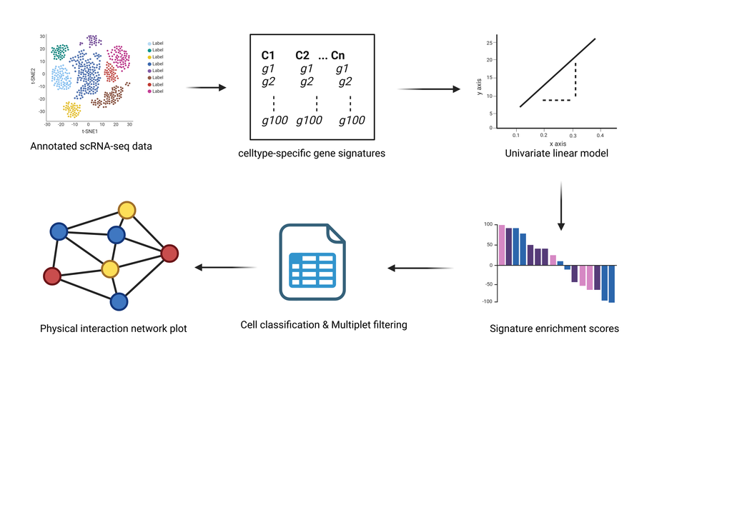

We first load the ULM package

```r
library(ULM)
```

In this vignette, we first test ULM on a scRNAseq dataset of small intestinal tissue (Andrews et al., 2021, pubmed: GSE175664). The preprocessed scRNAseq can be loaded by running this code:

```r
data("int_singData")
int_singData
```

```
#> An object of class Seurat
#> 15610 features across 5279 samples within 1 assay
#> Active assay: RNA (15610 features, 2000 variable features)
#>  3 layers present: counts, data, scale.data
#>  2 dimensional reductions calculated: pca, umap
```

Let us visualise the metadata to see the available cell annotations

```r
head(int_singData@meta.data)
```

```
#>                     orig.ident nCount_RNA nFeature_RNA          Cell_Type
#> AAACGAAAGAGGTCGT SeuratProject       6540         2190   Progenitor early
#> AAACGAAAGCCTCCAG SeuratProject      11193         3062  Progenitor late-1
#> AAACGAAAGTTTGGCT SeuratProject      12139         3234   Progenitor early
#> AAACGAACACAAGCTT SeuratProject      12188         3445 Transit amplifying
#> AAACGAAGTCGCTTGG SeuratProject       2493         1112  Progenitor late-2
#> AAACGAAGTCTTACTT SeuratProject       7547         2686             Goblet
#>                                       Source Subject_strain          Tissue
#> AAACGAAAGAGGTCGT Small Intestinal Epithelium       C57BL/6J Small Intestine
#> AAACGAAAGCCTCCAG Small Intestinal Epithelium       C57BL/6J Small Intestine
#> AAACGAAAGTTTGGCT Small Intestinal Epithelium       C57BL/6J Small Intestine
#> AAACGAACACAAGCTT Small Intestinal Epithelium       C57BL/6J Small Intestine
#> AAACGAAGTCGCTTGG Small Intestinal Epithelium       C57BL/6J Small Intestine
#> AAACGAAGTCTTACTT Small Intestinal Epithelium       C57BL/6J Small Intestine
#>                  Pass_QC RNA_snn_res.0.3 seurat_clusters
#> AAACGAAAGAGGTCGT    TRUE               2               2
#> AAACGAAAGCCTCCAG    TRUE               3               3
#> AAACGAAAGTTTGGCT    TRUE               0               0
#> AAACGAACACAAGCTT    TRUE               0               0
#> AAACGAAGTCGCTTGG    TRUE               6               6
#> AAACGAAGTCTTACTT    TRUE               1               1
```

As we can see, there is a ‘Cell_Type’ column that contains cell annotations. Let us visualize the annotated Seurat clusters

```r
library(Seurat)
```

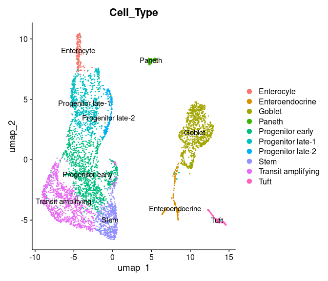

```r
DimPlot(int_singData, reduction="umap", group.by="Cell_Type", label=TRUE)
```

Now let us use the ULM pipeline to identify multiplets present in this data and infer physical interaction network.

The first step in the pipeline is to generate cell type-specific gene signatures. This will generate a default of 100 genes that best mark each annotated cell type cluster in the data.

```r
set.seed(101324)
int_sig <- GetSignature(int_singData, ident_col = int_singData$Cell_Type, n = 100)
```

```
#> using the specified seurat ident to generate signatures
```

Let us visualize what the signature table looks like

```r
head(int_sig, 10)
```

```
#> # A tibble: 10 × 3
#> # Groups:   source [1]
#>    source           target          mor
#>    <chr>            <chr>         <dbl>
#>  1 Progenitor early Ccna1             1
#>  2 Progenitor early Hist1h2br         1
#>  3 Progenitor early BC051077          1
#>  4 Progenitor early Gm10501           1
#>  5 Progenitor early C330021F23Rik     1
#>  6 Progenitor early Cdkn3             1
#>  7 Progenitor early Cdc25c            1
#>  8 Progenitor early Ccnb2             1
#>  9 Progenitor early Cdc20             1
#> 10 Progenitor early Lipg              1
```

The signature table has 3 columns, the source column contains the cell type, the target column contains the genes and the mor column contains the weights.

Next, we score each cell in the scRNseq data for cell signatures by fitting univariate linear models. We will score the signatures on each barcode (cell) in the normalised gene count matrix (found in the slot = data). To use the raw count, set slot = ‘count’

```r
my_scores <- GetCellScores(seurat_obj = int_singData, signatures = int_sig, assay = 'RNA', slot = 'data')
```

Let us visualize the cell score data frame

```r
head(my_scores, 10)
```

```
#> # A tibble: 10 × 5
#>    barcode          celltype   score   p_value statistic
#>    <chr>            <chr>      <dbl>     <dbl> <chr>
#>  1 AAACGAAAGAGGTCGT Enterocyte -3.20 0.00136   ulm
#>  2 AAACGAAAGCCTCCAG Enterocyte -3.30 0.000974  ulm
#>  3 AAACGAAAGTTTGGCT Enterocyte -3.88 0.000106  ulm
#>  4 AAACGAACACAAGCTT Enterocyte -4.31 0.0000164 ulm
#>  5 AAACGAAGTCGCTTGG Enterocyte -1.22 0.221     ulm
#>  6 AAACGAAGTCTTACTT Enterocyte -4.01 0.0000622 ulm
#>  7 AAACGAAGTTACCCTC Enterocyte -3.00 0.00268   ulm
#>  8 AAACGAATCACCGGTG Enterocyte -4.01 0.0000601 ulm
#>  9 AAACGCTAGAGTCAAT Enterocyte -1.93 0.0535    ulm
#> 10 AAACGCTAGATGAATC Enterocyte -3.71 0.000212  ulm
```

As seen, the cell score data frame contains the scores of barcodes for each cell signature as well as the p values. Positive scores infer enriched signatures while negative scores infer non-enriched signatures for each barcode.

Next is to label each barcode by cell types based on the signature scores. Cells with one significant signature score will have a single-cell label while cells with more than one significant signature score will have a multi-cell label. Please note that barcodes and cells are used interchangeably.

```r
my_ass <- GetCellAssignments(score_data = my_scores, cut_off = 1, p_val = 0.05)
```

We choose a cut-off of 1 to depict enriched signatures. This means that we considered all negative scores and those below 1 as non-enriched. Ideally, all positive scores should be considered enriched but choosing a cut-off of 1 will increase precision of our cell assignment. However, users may choose to set the cut-off at 0 or higher. Note that there is a trade off between cutoff and cell dropout.

Let us visualize the cell assignment data frame.

```r
head(my_ass, 10)
```

```
#>             barcode statistic count_ulm                        celltype_ulm
#> 1  AAAGGTATCGGCTTCT       ulm         2        Enterocyte_Progenitor late-1
#> 2  AACAGGGAGAAGTCAT       ulm         2        Enterocyte_Progenitor late-1
#> 3  AACCAACCATCAGCAT       ulm         2        Enterocyte_Progenitor late-1
#> 4  AACCTGAGTACCGTCG       ulm         3 Enterocyte_Paneth_Progenitor late-1
#> 5  AACGAAACAAGCGCAA       ulm         2        Enterocyte_Progenitor late-1
#> 6  AACGAAACAGGTCCCA       ulm         2        Enterocyte_Progenitor late-1
#> 7  AACGGGAAGTGACACG       ulm         2        Enterocyte_Progenitor late-1
#> 8  AACGGGATCCATACTT       ulm         2        Enterocyte_Progenitor late-1
#> 9  AACGGGATCGTAGCTA       ulm         2        Enterocyte_Progenitor late-1
#> 10 AAGAACAAGTTCTACG       ulm         2        Enterocyte_Progenitor late-1
#>      avg_pvalue avg_score
#> 1  2.523098e-13  8.319202
#> 2  2.424298e-15  8.761571
#> 3  9.232242e-16  8.127915
#> 4  8.578408e-06  7.990285
#> 5  2.859176e-09  5.994553
#> 6  1.859488e-17  8.907267
#> 7  2.196144e-06  6.576429
#> 8  5.995422e-15  8.042991
#> 9  1.101760e-17 10.222142
#> 10 2.110035e-04  4.999832
```

As we can see, the cell assignment data frame has a dedicated column called “count_ulm” which tells how many cell signatures a given barcode has. For example, a count_ulm value of 2 means that the barcode has a significant score for two different signatures and as such it is a predicted doublet, while a value of 3 represents a predicted triplet. Also, the “celltype_ulm” column contains the specific signatures that a barcode expresses. For example, the first 3 barcodes have count_ulm values of 2 and the associated cell labels are “Enterocyte_Progenitor late-1” as seen in the celltype_ulm column. This means that those barcodes are cells (doublets) that were enriched in dual gene signatures.

Now that we have predicted each barcode in the data and assigned labels to them based on cell type-specific gene sigatures, we can then add the new labels and the associated statistics to the metadata of our Seurat Object. Let us view the metadata once again before we add the predicted labels

```r
head(int_singData@meta.data)
```

```
#>                     orig.ident nCount_RNA nFeature_RNA          Cell_Type
#> AAACGAAAGAGGTCGT SeuratProject       6540         2190   Progenitor early
#> AAACGAAAGCCTCCAG SeuratProject      11193         3062  Progenitor late-1
#> AAACGAAAGTTTGGCT SeuratProject      12139         3234   Progenitor early
#> AAACGAACACAAGCTT SeuratProject      12188         3445 Transit amplifying
#> AAACGAAGTCGCTTGG SeuratProject       2493         1112  Progenitor late-2
#> AAACGAAGTCTTACTT SeuratProject       7547         2686             Goblet
#>                                       Source Subject_strain          Tissue
#> AAACGAAAGAGGTCGT Small Intestinal Epithelium       C57BL/6J Small Intestine
#> AAACGAAAGCCTCCAG Small Intestinal Epithelium       C57BL/6J Small Intestine
#> AAACGAAAGTTTGGCT Small Intestinal Epithelium       C57BL/6J Small Intestine
#> AAACGAACACAAGCTT Small Intestinal Epithelium       C57BL/6J Small Intestine
#> AAACGAAGTCGCTTGG Small Intestinal Epithelium       C57BL/6J Small Intestine
#> AAACGAAGTCTTACTT Small Intestinal Epithelium       C57BL/6J Small Intestine
#>                  Pass_QC RNA_snn_res.0.3 seurat_clusters
#> AAACGAAAGAGGTCGT    TRUE               2               2
#> AAACGAAAGCCTCCAG    TRUE               3               3
#> AAACGAAAGTTTGGCT    TRUE               0               0
#> AAACGAACACAAGCTT    TRUE               0               0
#> AAACGAAGTCGCTTGG    TRUE               6               6
#> AAACGAAGTCTTACTT    TRUE               1               1
```

Now let us add the predicted labels and view the metadata.

```r
int_singData <- AddMetaObject(int_singData, cell_class_df = my_ass)
```

```r
head(int_singData@meta.data)
```

```
#>                     orig.ident nCount_RNA nFeature_RNA          Cell_Type
#> AAACGAAAGAGGTCGT SeuratProject       6540         2190   Progenitor early
#> AAACGAAAGCCTCCAG SeuratProject      11193         3062  Progenitor late-1
#> AAACGAAAGTTTGGCT SeuratProject      12139         3234   Progenitor early
#> AAACGAACACAAGCTT SeuratProject      12188         3445 Transit amplifying
#> AAACGAAGTCGCTTGG SeuratProject       2493         1112  Progenitor late-2
#> AAACGAAGTCTTACTT SeuratProject       7547         2686             Goblet
#>                                       Source Subject_strain          Tissue
#> AAACGAAAGAGGTCGT Small Intestinal Epithelium       C57BL/6J Small Intestine
#> AAACGAAAGCCTCCAG Small Intestinal Epithelium       C57BL/6J Small Intestine
#> AAACGAAAGTTTGGCT Small Intestinal Epithelium       C57BL/6J Small Intestine
#> AAACGAACACAAGCTT Small Intestinal Epithelium       C57BL/6J Small Intestine
#> AAACGAAGTCGCTTGG Small Intestinal Epithelium       C57BL/6J Small Intestine
#> AAACGAAGTCTTACTT Small Intestinal Epithelium       C57BL/6J Small Intestine
#>                  Pass_QC RNA_snn_res.0.3 seurat_clusters statistic count_ulm
#> AAACGAAAGAGGTCGT    TRUE               2               2      <NA>        NA
#> AAACGAAAGCCTCCAG    TRUE               3               3       ulm         1
#> AAACGAAAGTTTGGCT    TRUE               0               0      <NA>        NA
#> AAACGAACACAAGCTT    TRUE               0               0      <NA>        NA
#> AAACGAAGTCGCTTGG    TRUE               6               6       ulm         2
#> AAACGAAGTCTTACTT    TRUE               1               1       ulm         1
#>                                         celltype_ulm   avg_pvalue avg_score
#> AAACGAAAGAGGTCGT                                <NA>           NA        NA
#> AAACGAAAGCCTCCAG                   Progenitor late-1 1.785378e-04  3.748499
#> AAACGAAAGTTTGGCT                                <NA>           NA        NA
#> AAACGAACACAAGCTT                                <NA>           NA        NA
#> AAACGAAGTCGCTTGG Progenitor late-1_Progenitor late-2 5.336437e-04  4.889417
#> AAACGAAGTCTTACTT                              Goblet 6.233197e-06  4.519871
```

The final steps in the pipeline involve isolating multiplets and plotting physical cell-cell interaction network. Let us isolate the multiplets from our Seurat Object, setting minCells = 2, meaning we want barcodes of doublets and above. Set minCells to 3 if you want triplets and above etc.

```r
my_mult <- GetMultiplet(int_singData, minCells = 2)
```

This generates a list containing a multiplet Seurat Object and a multiplet. The multiplet summary shows multiplet types and frequency. Let us show the multiplet summary table.

```r
multSummary <- my_mult$multSummary
multSummary
```

```
#>                                            multipletType frequency
#> 1           Enterocyte_Enteroendocrine_Progenitor late-1         1
#> 2                    Enterocyte_Goblet_Progenitor late-1         3
#> 3                    Enterocyte_Paneth_Progenitor late-1         2
#> 4                           Enterocyte_Progenitor late-1       216
#> 5         Enterocyte_Progenitor late-1_Progenitor late-2        12
#> 6                                 Enteroendocrine_Goblet         3
#> 7                       Enteroendocrine_Progenitor early         1
#> 8                                          Goblet_Paneth       104
#> 9                       Goblet_Paneth_Transit amplifying         2
#> 10                                    Goblet_Paneth_Tuft         1
#> 11                               Goblet_Progenitor early        14
#> 12            Goblet_Progenitor early_Transit amplifying         1
#> 13                              Goblet_Progenitor late-1         4
#> 14                              Goblet_Progenitor late-2         1
#> 15                             Goblet_Transit amplifying        21
#> 16                                           Goblet_Tuft         3
#> 17                               Paneth_Progenitor early         3
#> 18                          Paneth_Progenitor early_Stem         1
#> 19                              Paneth_Progenitor late-1         2
#> 20                             Paneth_Transit amplifying         2
#> 21                    Progenitor early_Progenitor late-1         9
#> 22 Progenitor early_Progenitor late-1_Transit amplifying         1
#> 23                    Progenitor early_Progenitor late-2         1
#> 24                                 Progenitor early_Stem         4
#> 25              Progenitor early_Stem_Transit amplifying         1
#> 26                   Progenitor early_Transit amplifying       148
#> 27                   Progenitor late-1_Progenitor late-2       136
#> 28                  Progenitor late-1_Transit amplifying         1
```

We can also see the total number of predicted multiplets from the summary table

```r
sum(multSummary$frequency)
```

```
#> [1] 698
```

The multiplet Seurat Object is just a typical object that can be utilised for multiplet modeling or any downstream analysis as the user pleases. Let us see the multiplet Seurat Object.

```r
multObj <- my_mult$multObj
multObj
```

```
#> An object of class Seurat
#> 15610 features across 698 samples within 1 assay
#> Active assay: RNA (15610 features, 2000 variable features)
#>  3 layers present: counts, data, scale.data
#>  2 dimensional reductions calculated: pca, umap
```

We can also see the multiplet order from the multiplet object

```r
table(multObj$count_ulm)
```

```
#>
#>   2   3
#> 673  25
```

There are 698 multiplets i total, of these, 673 were doublets and 25 are triplets.

```r
my_mult_filt <- FilterMultiplet(int_singData, minCells = 2, minFreq = 10)
```

```r
multSummaryFilt <- my_mult_filt$multSummaryFilt
multSummaryFilt
```

```
#>                                     multipletType frequency
#> 4                    Enterocyte_Progenitor late-1       216
#> 5  Enterocyte_Progenitor late-1_Progenitor late-2        12
#> 8                                   Goblet_Paneth       104
#> 11                        Goblet_Progenitor early        14
#> 15                      Goblet_Transit amplifying        21
#> 26            Progenitor early_Transit amplifying       148
#> 27            Progenitor late-1_Progenitor late-2       136
```

We can similarly explore the filtered multiplet object. Again, this can be used for downstream analysis as a typical scRNAseq data if the user pleases.

```r
multObjFilt <- my_mult_filt$multObjFilt
multObjFilt
```

```
#> An object of class Seurat
#> 15610 features across 651 samples within 1 assay
#> Active assay: RNA (15610 features, 2000 variable features)
#>  3 layers present: counts, data, scale.data
#>  2 dimensional reductions calculated: pca, umap
```

Finally, we will plot a cell-cell interaction network from the filtered multiplets. To do this, we need to first decompose the filtered multiplet summary table in to a pairwise node-edge data frame.

```r
my_node_df <- GetNodeDF(mat = multSummaryFilt)
```

Let us view the pairwise node-edge dataframeformed

```r
my_node_df
```

```
#>               Cell1              Cell2 n_cells
#> 1            Goblet             Paneth     104
#> 2            Goblet   Progenitor early      14
#> 3        Enterocyte  Progenitor late-1     228
#> 4        Enterocyte  Progenitor late-2      12
#> 5 Progenitor late-1  Progenitor late-2     148
#> 6            Goblet Transit amplifying      21
#> 7  Progenitor early Transit amplifying     148
```

Finally, we can plot the physical interaction network

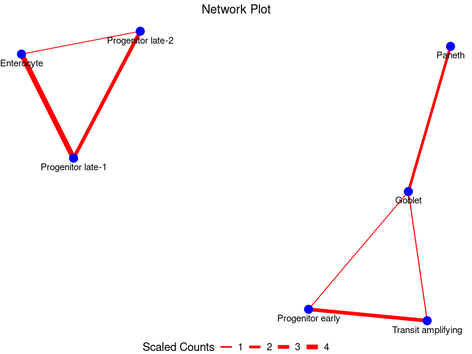

```r
PlotNetwork(my_node_df)
```

Indeed, we see interactions involving progenitors and other intestinal epithelial cells. This is biologically plausible since progenitor cells are known to transition through stages to replace the rapidly old intestinal epithelial cells such as enterocyte, transit amplifying cells and goblet cells.

In the final part of this vignette, we show that it is also possible to use a reference scRNAseq data set to generate signatures which can then be utilised to predict multiplet and depict physical interactions in a different query scRNAseq data of similar tissue of origin. For this purpose, we use the intestinal scRNAseq data above as reference to generate signatures. We will then utilise this to predict multiplets in a query dataset of partially dissociated intestinal scRNAseq data from the same study (Andrews et al., 2021, pubmed: GSE175664). We load query and reference data sets

```r
data("int_singData")
ref_obj <- int_singData
ref_obj
```

```
#> An object of class Seurat
#> 15610 features across 5279 samples within 1 assay
#> Active assay: RNA (15610 features, 2000 variable features)
#>  3 layers present: counts, data, scale.data
#>  2 dimensional reductions calculated: pca, umap
```

```r
data("int_multData")
query_obj <- int_multData
query_obj
```

```
#> An object of class Seurat
#> 15615 features across 3671 samples within 1 assay
#> Active assay: RNA (15615 features, 2000 variable features)
#>  3 layers present: counts, data, scale.data
#>  2 dimensional reductions calculated: pca, umap
```

Let us generate signatures from the reference dataset

```r
set.seed(101324)
ref_sig <- GetSignature(ref_obj, ident_col = ref_obj$Cell_Type)
```

```
#> using the specified seurat ident to generate signatures
```

```r
head(ref_sig, 10)
```

```
#> # A tibble: 10 × 3
#> # Groups:   source [1]
#>    source           target          mor
#>    <chr>            <chr>         <dbl>
#>  1 Progenitor early Ccna1             1
#>  2 Progenitor early Hist1h2br         1
#>  3 Progenitor early BC051077          1
#>  4 Progenitor early Gm10501           1
#>  5 Progenitor early C330021F23Rik     1
#>  6 Progenitor early Cdkn3             1
#>  7 Progenitor early Cdc25c            1
#>  8 Progenitor early Ccnb2             1
#>  9 Progenitor early Cdc20             1
#> 10 Progenitor early Lipg              1
```

NB: It is also possible to directly import and utilize a reference signature but this must be formatted to suit the output of the GetSignature() function above. That is, it must be a data frame (or tibble) with 3 columns- source, target and mor, containing the cell type, signatures and weight (=1) respectively.

We then utilize the reference signature to predict multiplets in the query data set and construct a physical cell-cell interaction network.

Getting query cell scores

```r
my_scores <- GetCellScores(seurat_obj = query_obj, signatures = ref_sig, assay = 'RNA', slot = 'data')
```

Assigning cell labels

```r
my_ass <- GetCellAssignments(score_data = my_scores)
```

Adding cell labels to the metadata

```r
lab_query_obj <- AddMetaObject(query_obj, cell_class_df = my_ass)
```

Obtaining predicted multiplets

```r
query_mult <- GetMultiplet(lab_query_obj)
```

Multiplet summary table

```r
query_multSummary <- query_mult$multSummary
query_multSummary
```

```
#>                                            multipletType frequency
#> 1           Enterocyte_Enteroendocrine_Progenitor late-1         1
#> 2                    Enterocyte_Goblet_Progenitor late-1         9
#> 3  Enterocyte_Goblet_Progenitor late-1_Progenitor late-2         1
#> 4                    Enterocyte_Paneth_Progenitor late-1         5
#> 5  Enterocyte_Paneth_Progenitor late-1_Progenitor late-2         1
#> 6                           Enterocyte_Progenitor late-1       256
#> 7         Enterocyte_Progenitor late-1_Progenitor late-2        57
#> 8                      Enterocyte_Progenitor late-1_Tuft         2
#> 9                                 Enteroendocrine_Goblet         1
#> 10                         Enteroendocrine_Goblet_Paneth         1
#> 11                      Enteroendocrine_Progenitor early         6
#> 12                     Enteroendocrine_Progenitor late-1         1
#> 13                    Enteroendocrine_Transit amplifying         2
#> 14                                         Goblet_Paneth       211
```

[output cut: 19 more lines]

Multiplet order

```r
query_multObj <- query_mult$multObj
query_multObj
```

```
#> An object of class Seurat
#> 15615 features across 999 samples within 1 assay
#> Active assay: RNA (15615 features, 2000 variable features)
#>  3 layers present: counts, data, scale.data
#>  2 dimensional reductions calculated: pca, umap
```

```r
table(query_multObj$count_ulm)
```

```
#>
#>   2   3   4
#> 904  93   2
```

Filtering multiplets

```r
query_mult_filt <- FilterMultiplet(lab_query_obj, minFreq = 7)
```

Filtered multiplet summary table

```r
query_multSummaryFilt <- query_mult_filt$multSummaryFilt
query_multSummaryFilt
```

```
#>                                     multipletType frequency
#> 2             Enterocyte_Goblet_Progenitor late-1         9
#> 6                    Enterocyte_Progenitor late-1       256
#> 7  Enterocyte_Progenitor late-1_Progenitor late-2        57
#> 14                                  Goblet_Paneth       211
#> 16                        Goblet_Progenitor early        83
#> 18                       Goblet_Progenitor late-1        18
#> 20                       Goblet_Progenitor late-2         8
#> 21                      Goblet_Transit amplifying        25
#> 22                        Paneth_Progenitor early        15
#> 27                      Paneth_Transit amplifying         9
#> 30            Progenitor early_Transit amplifying        79
#> 32            Progenitor late-1_Progenitor late-2       174
```

Generating pairwise node-edge data frame from the filtered multiplet summary table

```r
query_network_df <- GetNodeDF(mat = query_multSummaryFilt)
```

Plotting query cell-cell interaction network

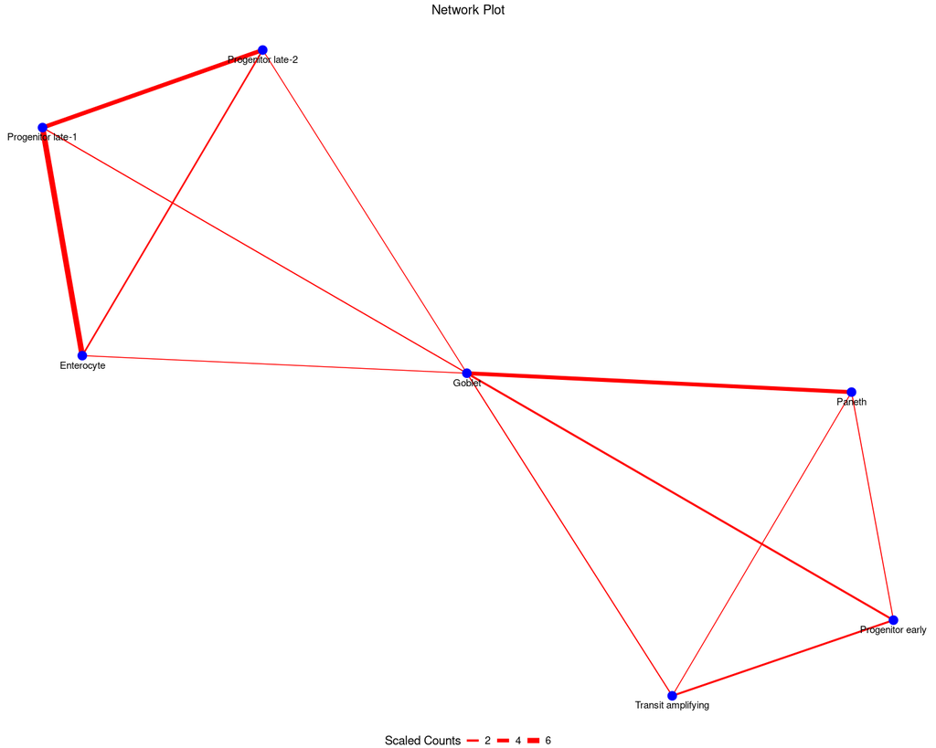

```r
PlotNetwork(query_network_df)
```

THE END

Reference

Andrews N, Serviss JT, Geyer N, Andersson AB, Dzwonkowska E, Šutevski I, et al. An unsupervised method for physical cell interaction profiling of complex tissues. Nat Methods. 2021;18:912–20.